# Лабораторная работа №6

Имитационное моделирование

Брыляков Никита Евгеньевич

1132236044@rudn.ru

Российский университет дружбы народов

2026-04-28

## Цель работы

Целью данной лабораторной работы является реализация модели эпидемии SIR с использованием сетей Петри и анализ результата действия данной модели.

## Выполнение лабораторной работы

Предварительно проверим правильность структуры нашего проекта (рис. 1).

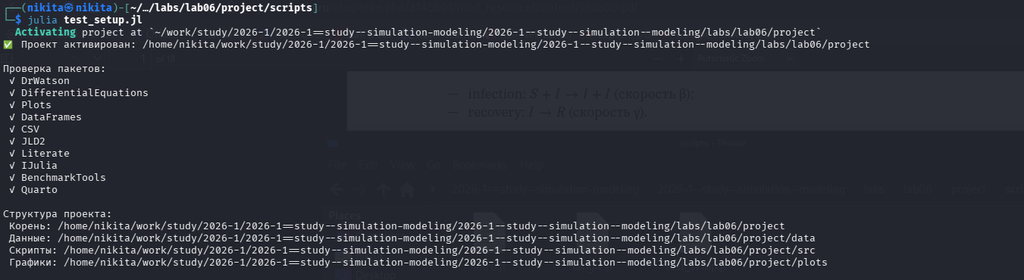

Рисунок 1: Проверка структуры проекта

## Код модели

Создадим файл src/SIRPetri.jl с реализацией вычислительной логики модели (рис. 2).

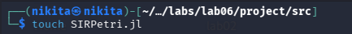

Рисунок 2: Код модели

## Базовый прогон модели

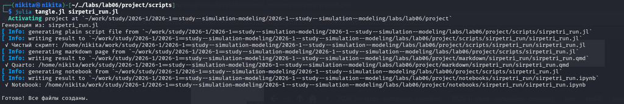

## Базовый прогон модели

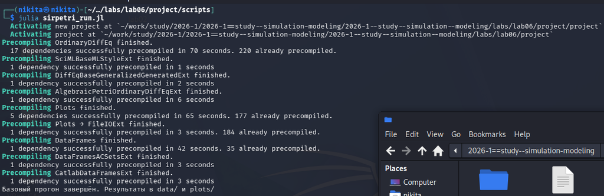

## Базовый прогон модели

Запустим файл ipynb в jupyter-notebook (рис. 6).

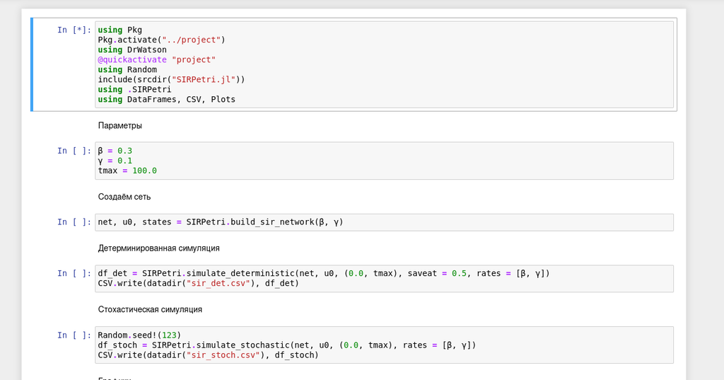

Рисунок 6: Запуск файла в jupyter-notebook

## Коэффициент заражения β

Создадим файл scripts/sirpetri_scan_parameters.jl. Скрипт исследует чувствительность модели к изменению параметра β (скорости заражения). Для каждого значения β из диапазона 0.1:0.05:0.8 запускается детерминированная симуляция (γ = 0.1 фиксирован). Для каждого прогона вычисляются: максимальное число инфицированных (пик эпидемии) – peak_I и конечное число выздоровевших – final_R (рис. 7).

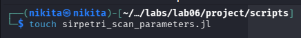

Рисунок 7: Коэффициент заражения β

## Коэффициент заражения β

Запустим скрипт (рис. 8).

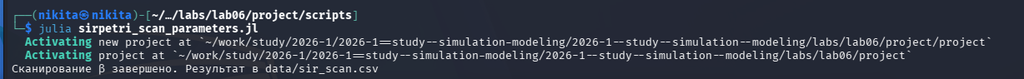

Рисунок 8: Коэффициент заражения β

## Коэффициент заражения β

Создадим производные форматы с помощью скрипта tangle.jl (рис. 9).

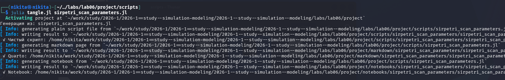

Рисунок 9: Создание производных форматов

## Коэффициент заражения β

Запустим файл ipynb в jupyter-notebook (рис. 10).

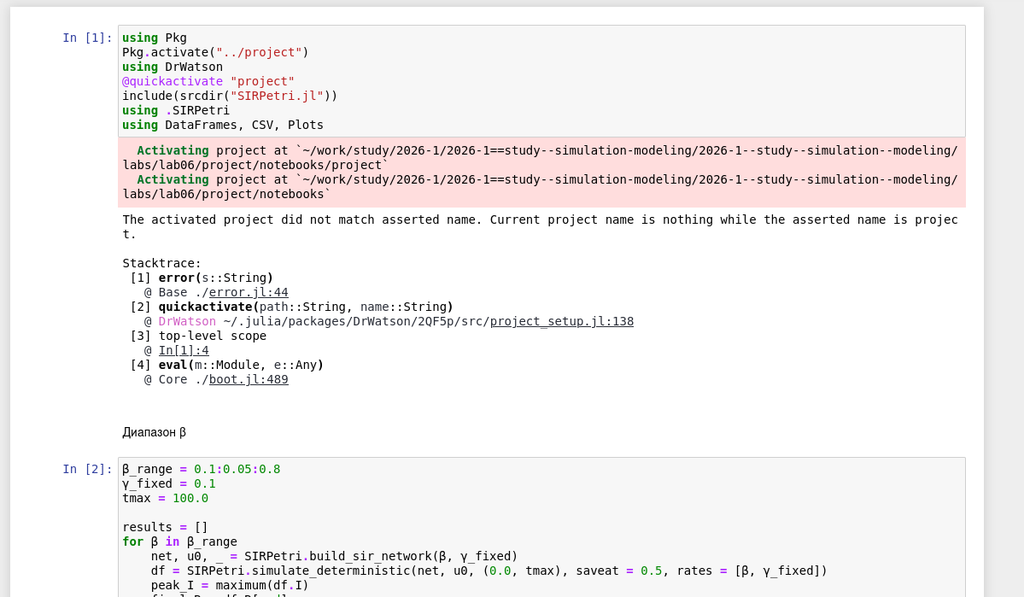

Рисунок 10: Запуск файла в jupyter-notebook

## Анимация детерминированной динамики

Создадим файл scripts/sirpetri_animate.jl. Скрипт создаёт GIF-анимацию, показывающую, как со временем меняется количество людей в каждой из трёх групп (S,I,R). Анимация позволяет наглядно увидеть распространение эпидемии, пик и спад (рис. 11).

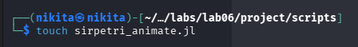

Рисунок 11: Анимация детерминированной динамики

## Анимация детерминированной динамики

Запустим скрипт (рис. 12).

[figure not shown]

Рисунок 12: Анимация детерминированной динамики

## Анимация детерминированной динамики

Создадим производные форматы с помощью скрипта tangle.jl (рис. 13).

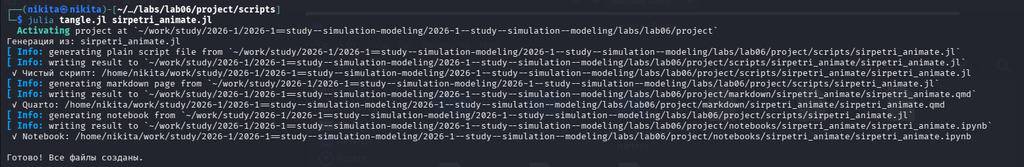

Рисунок 13: Создание производных форматов

## Анимация детерминированной динамики

Запустим файл ipynb в jupyter-notebook (рис. 14).

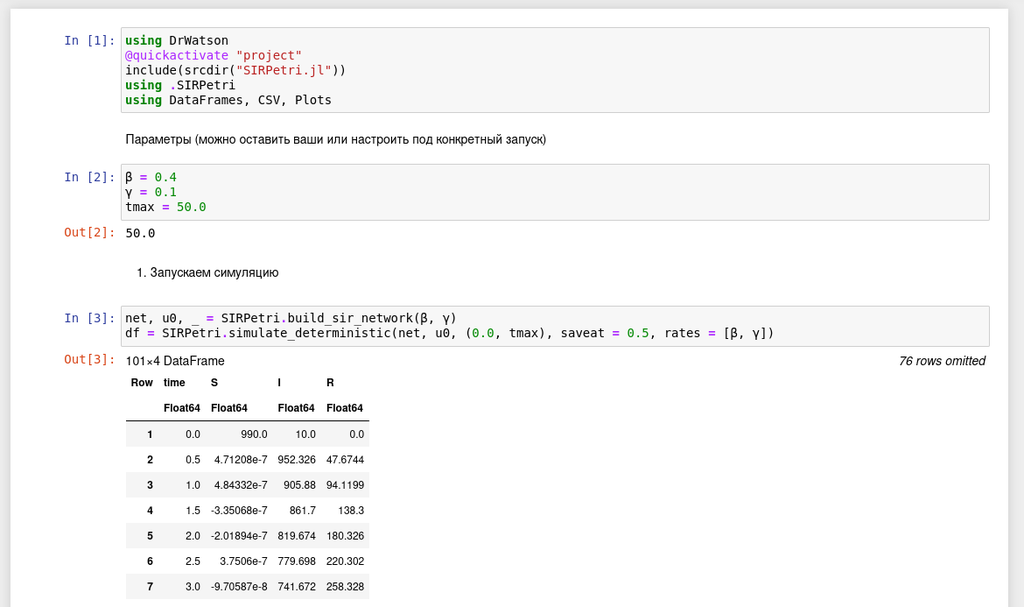

Рисунок 14: Запуск файла в jupyter-notebook

## Итоговый отчёт

Создадим файл scripts/sirpetri_report.jl. Скрипт загружает ранее сохранённые результаты (sir_det.csv, sir_stoch.csv, sir_scan.csv) и строит сравнительные графики для итогового отчёта (рис. 15).

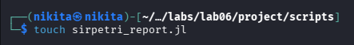

Рисунок 15: Итоговый отчёт

## Итоговый отчёт

Запустим скрипт (рис. 16).

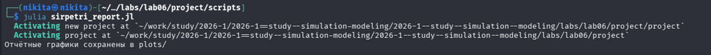

Рисунок 16: Итоговый отчёт

## Итоговый отчёт

Создадим производные форматы с помощью скрипта tangle.jl (рис. 17).

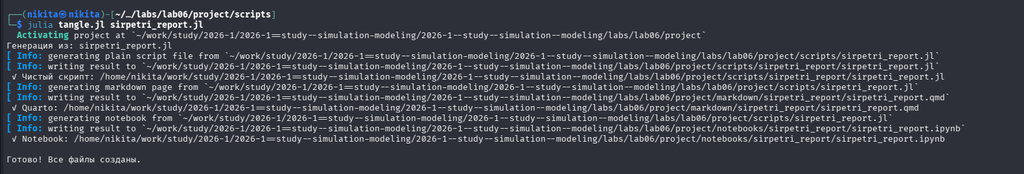

Рисунок 17: Создание производных форматов

## Итоговый отчёт

Запустим файл ipynb в jupyter-notebook (рис. 18).

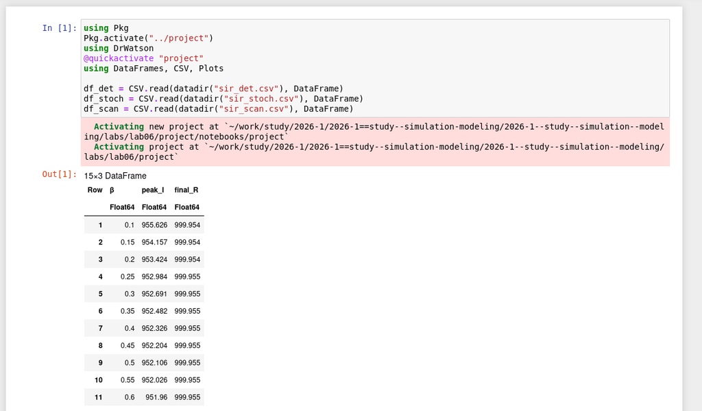

Рисунок 18: Запуск файла в jupyter-notebook

## Выводы

В ходе данной лабораторной работы мной была реализована модель эпидемии SIR с использованием сетей Петри и проанализирован результат действия данной модели.